# Analyse des Taux des Bons du Trésor à 10 Ans

GUIZANI HAMZA

2025-01-20

# Introduction

Ce document analyse les taux des bons du Trésor américains. Il inclut la préparation des données, l’exploration des séries temporelles, et les prévisions. Le jeu de données contient des observations périodiques sur les rendements des titres du Trésor américain, exprimés en pourcentage. Les taux d’intérêt sont généralement observés sur différentes échéances, mais dans le cadre de cette analyse, nous nous concentrons sur le taux (identifiant de série : DGS10).

# Origine et source

Les données proviennent de la Federal Reserve Economic Data (FRED) , une base de données économiques et financières gérée par la Federal Reserve Bank of St. Louis. L’API FRED est une ressource officielle et fiable, offrant un accès direct à des milliers d’indicateurs économiques.

## Aperçu

Nous utilisons des bibliothèques populaires pour la manipulation, la modélisation et la visualisation.

## Installation des packages nécessaires

```r
#install.packages("forecast")
#install.packages("fredr")
#install.packages("tidyverse")
#install.packages("lubridate")
#install.packages("tseries")
#install.packages("zoo")
#install.packages("dygraphs")
#install.packages("ggplot2")
#install.packages("dplyr")
```

## Chargement des bibliothèques nécessaires

```r
library(tidyverse)
library(lubridate)
library(zoo)
library(forecast)
library(tseries)
library(fredr)
```

```r
library(dygraphs)
library(ggplot2)
library(dplyr)
```

## Configuration de la clé pour l’API FRED

```r
fredr_set_key("fded5e5cfee46964aad695ca7288a937")
```

# Jeu de données

Chargement des données des bons du Trésor américains à partir de la base de la Réserve fédérale avec fredr.

```r
data <- fredr(
  series_id = "DGS10",                       # Série FRED : taux des bons du Trésor américains
  observation_start = as.Date("1990-01-01"), # Date de début
  observation_end = as.Date("2023-12-31")    # Date de fin
)
```

# Analyses et Transformations

## Exploration de données

```r
head(data)
```

```
## # A tibble: 6 × 5
##   date       series_id value realtime_start realtime_end
##   <date>     <chr>     <dbl> <date>         <date>
## 1 1990-01-01 DGS10     NA    2025-01-20     2025-01-20
## 2 1990-01-02 DGS10      7.94 2025-01-20     2025-01-20
## 3 1990-01-03 DGS10      7.99 2025-01-20     2025-01-20
## 4 1990-01-04 DGS10      7.98 2025-01-20     2025-01-20
## 5 1990-01-05 DGS10      7.99 2025-01-20     2025-01-20
## 6 1990-01-08 DGS10      8.02 2025-01-20     2025-01-20
```

```r
str(data)
```

```
## tibble [8,870 × 5] (S3: tbl_df/tbl/data.frame)
##  $ date          : Date[1:8870], format: "1990-01-01" "1990-01-02" ...
##  $ series_id     : chr [1:8870] "DGS10" "DGS10" "DGS10" "DGS10" ...
##  $ value         : num [1:8870] NA 7.94 7.99 7.98 7.99 8.02 8.02 8.03 8.04 8.1 ...
##  $ realtime_start: Date[1:8870], format: "2025-01-20" "2025-01-20" ...
##  $ realtime_end  : Date[1:8870], format: "2025-01-20" "2025-01-20" ...
```

```r
summary(data)
```

```
##       date             series_id             value       realtime_start
##  Min.   :1990-01-01   Length:8870        Min.   :0.520   Min.   :2025-01-20
##  1st Qu.:1998-07-01   Class :character   1st Qu.:2.530   1st Qu.:2025-01-20
##  Median :2006-12-30   Mode  :character   Median :4.120   Median :2025-01-20
##  Mean   :2006-12-30                      Mean   :4.251   Mean   :2025-01-20
##  3rd Qu.:2015-06-30                      3rd Qu.:5.810   3rd Qu.:2025-01-20
##  Max.   :2023-12-29                      Max.   :9.090   Max.   :2025-01-20
##                                          NA's   :364
##   realtime_end
##  Min.   :2025-01-20
##  1st Qu.:2025-01-20
##  Median :2025-01-20
##  Mean   :2025-01-20
##  3rd Qu.:2025-01-20
##  Max.   :2025-01-20
##
```

## Visualisation des données originales

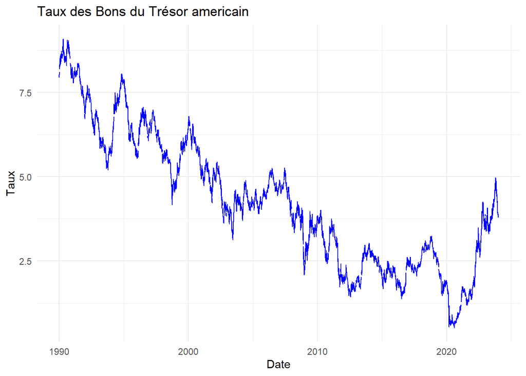

```r
ggplot(data, aes(x = date, y = value)) +
  geom_line(color = "blue") +
  labs(title = "Taux des Bons du Trésor americain", x = "Date", y = "Taux") +
  theme_minimal()
```

```r
dygraph(data)
```

[interactive chart not shown]

On observe une tendance générale à la baisse, reflétant la diminution progressive des taux d’intérêt au fil des décennies, souvent liée à des politiques monétaires accommodantes et à une inflation en déclin. Des fluctuations ponctuelles marquent des périodes de volatilité économique, telles que les crises financières en 2008 ou les ajustements de la politique monétaire. Après une chute marquée vers 2020 probablement en raison de la pandémie de COVID-19, les taux connaissent une reprise significative à partir de 2021. on remarque aussi des valeur manquante

## Détection et traitement des valeurs manquantes

```r
cat("Nombre de valeurs manquantes :", sum(is.na(data$value)), "\n")
```

```
## Nombre de valeurs manquantes : 364
```

```r
data$value <- zoo::na.locf(data$value, na.rm = FALSE, fromLast = TRUE)
data$value <- zoo::na.locf(data$value, na.rm = FALSE)
data$value <- zoo::na.approx(data$value, na.rm = FALSE)
cat("Valeurs manquantes après interpolation :", sum(is.na(data$value)), "\n")
```

```
## Valeurs manquantes après interpolation : 0
```

Détection et traitement des valeurs manquantes pour assurer la continuité et l’intégrité des données temporelles.

## Détection des valeurs aberrantes

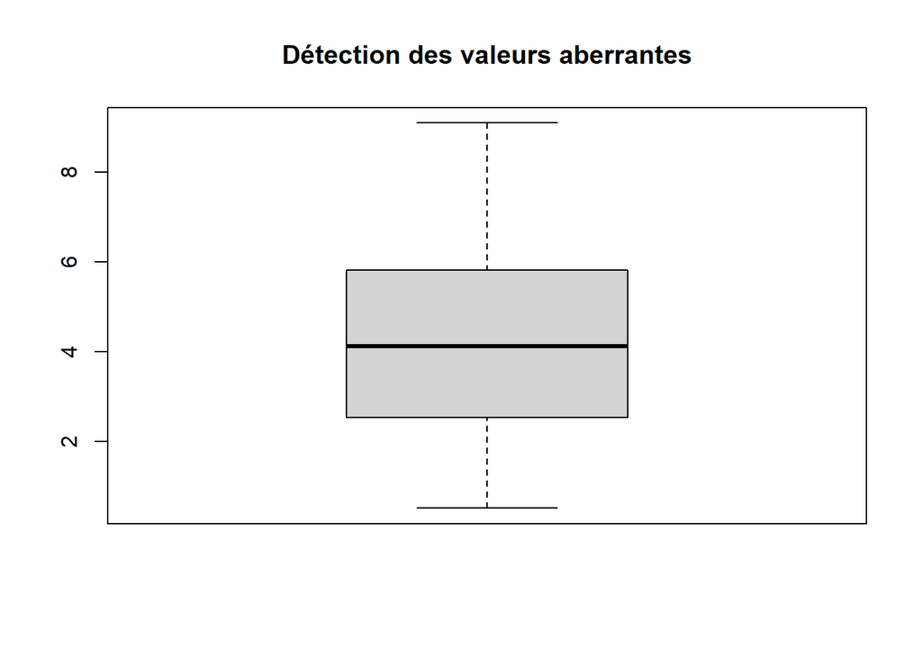

```r
iqr <- IQR(data$value, na.rm = TRUE)
lower_bound <- quantile(data$value, 0.25) - 1.5 * iqr
upper_bound <- quantile(data$value, 0.75) + 1.5 * iqr

data <- data %>% filter(value >= lower_bound & value <= upper_bound)

boxplot(data$value, main = "Détection des valeurs aberrantes")
```

Détection et filtrage Des valeurs aberrantes en utilisant l écart interquartile pour assurer la qualité des données. Ce boxplot illustre les caractéristiques principales des données restantes, qui sont contenues dans les limites des moustaches après suppression préalable des valeurs aberrantes.

## Conversion de la série avec une fréquence mensuelle

```r
data_mensuelle <- data %>%
  mutate(month = as.Date(cut(date, breaks = "month"))) %>%
  group_by(month) %>%
  summarize(value = mean(value, na.rm = TRUE))

ts_data_mensuelle <- ts(data_mensuelle$value, frequency = 12,
                        start = c(year(min(data$date)), month(min(data$date))))

dygraph(ts_data_mensuelle)
```

[interactive chart not shown]

## Division des données en ensembles d’apprentissage et de test

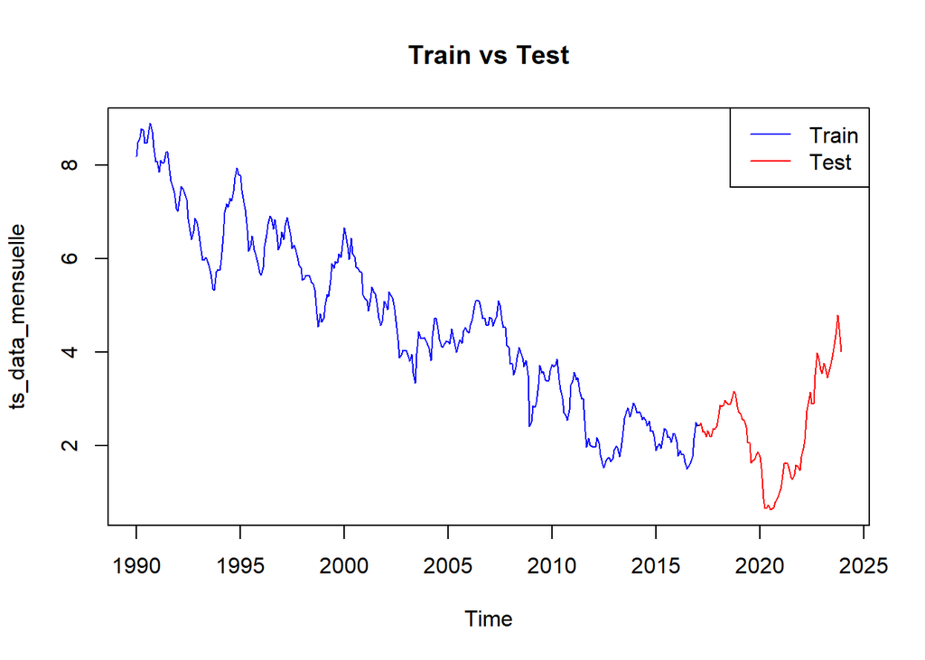

```r
train_size <- floor(0.8 * length(ts_data_mensuelle))
train_mensuelle <- window(ts_data_mensuelle, end = c(2017, 1))
test_mensuelle <- window(ts_data_mensuelle, start = c(2017, 2))

plot(ts_data_mensuelle, main = "Train vs Test")
lines(train_mensuelle, col = "blue")
lines(test_mensuelle, col = "red")
legend("topright", legend = c("Train", "Test"), col = c("blue", "red"), lty = 1)
```

## Analyse de la volatilité

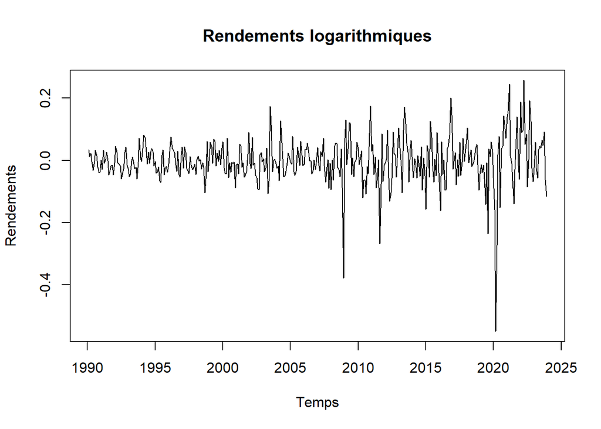

```r
log_returns <- diff(log(ts_data_mensuelle))
plot(log_returns, main="Rendements logarithmiques", ylab="Rendements", xlab="Temps")
```

```r
volatility <- sd(log_returns, na.rm = TRUE)
volatility
```

```
## [1] 0.07336309
```

## Modèles simples

```r
mean_model <- meanf(train_mensuelle, h = length(test_mensuelle))
naive_model <- naive(train_mensuelle, h = length(test_mensuelle))
drift_model <- rwf(train_mensuelle, drift = TRUE, h = length(test_mensuelle))
```

## Visualisation des prédictions simples

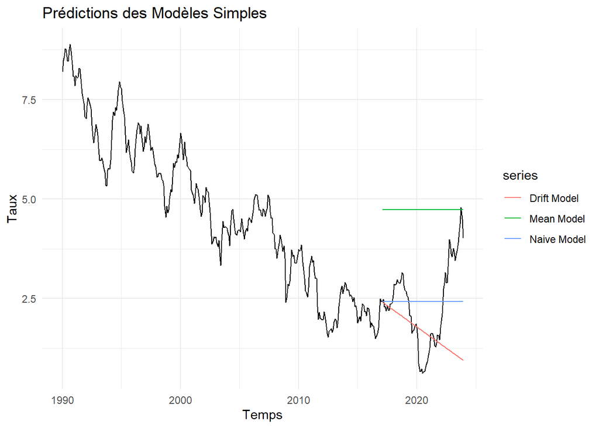

```r
autoplot(ts_data_mensuelle) +
  autolayer(mean_model$mean, series = "Mean Model") +
  autolayer(naive_model$mean, series = "Naive Model") +
  autolayer(drift_model$mean, series = "Drift Model") +
  labs(title = "Prédictions des Modèles Simples", x = "Temps", y = "Taux") +
  theme_minimal()
```

le modele Naive se comporte mieux en raison de sa capacité à refléter la dynamique récente.

## Décomposition de séries temporelles

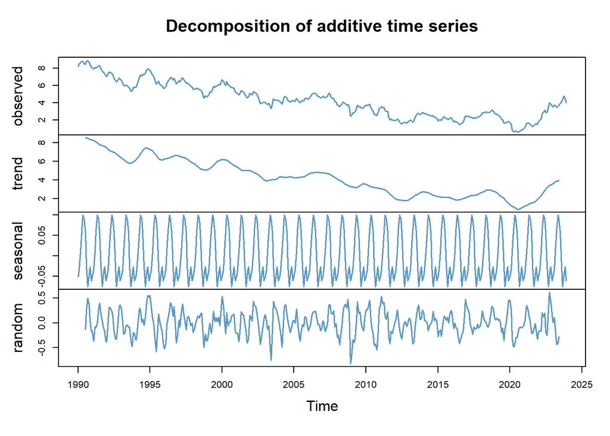

```r
decomp_add <- decompose(ts_data_mensuelle, type = "additive")
plot(decomp_add, col="#5A9AC7", lwd = 1.5)
```

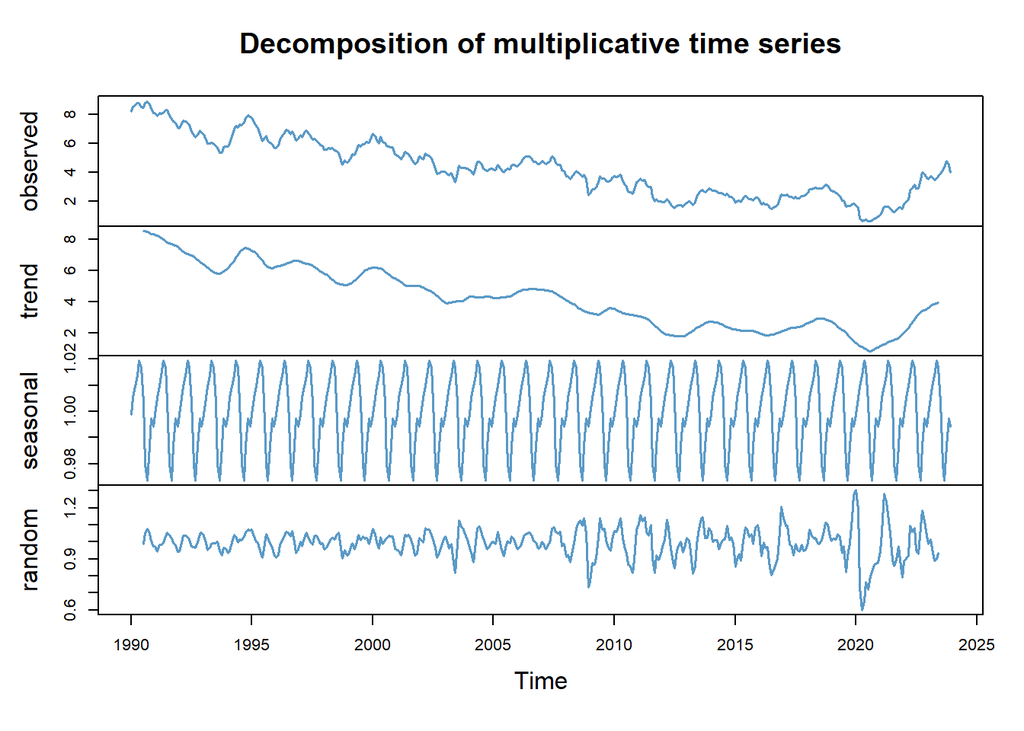

```r
decomp_mult <- decompose(ts_data_mensuelle, type = "multiplicative")
plot(decomp_mult, col="#5A9AC7", lwd = 1.5)
```

L’analyse montre une tendance générale, des variations saisonnières régulières, et des résidus indiquant des fluctuations non expliquées.

La décomposition révèle une tendance globale, des variations saisonnières proportionnelles, et des résidus montrant une augmentation de l’amplitude vers la fin.

## Extraction des composantes

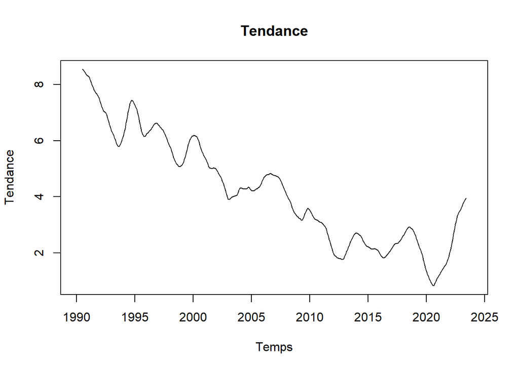

```r
trend <- decomp_add$trend
plot(trend, type = "l", main = "Tendance", xlab = "Temps", ylab = "Tendance")
```

La visualisation de la tendance permet seule de mieux observer l’évolution générale sur la période sans les fluctuations saisonnières et résiduelles..

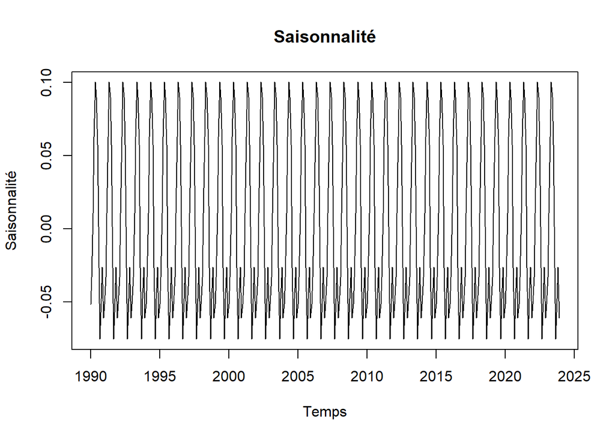

```r
seasonal <- decomp_add$seasonal
plot(seasonal, type = "l", main = "Saisonnalité", xlab = "Temps", ylab = "Saisonnalité")
```

La visualisation de la saisonnalité montre les variations périodiques récurrentes, mettant en évidence les schémas saisonniers au sein des données.

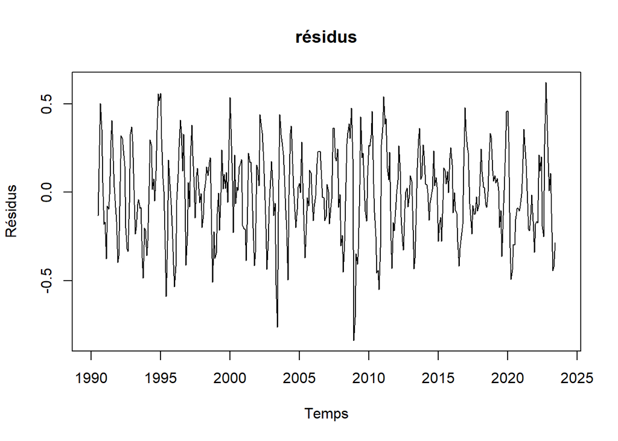

```r
residus <- decomp_add$random
plot(residus, type = "l", main = "résidus", xlab = "Temps", ylab = "Résidus")
```

L’analyse des résidus révèle les variations imprévues, affichant les fluctuations non expliquées par la tendance ou la saisonnalité.

# Graphique saisonnier

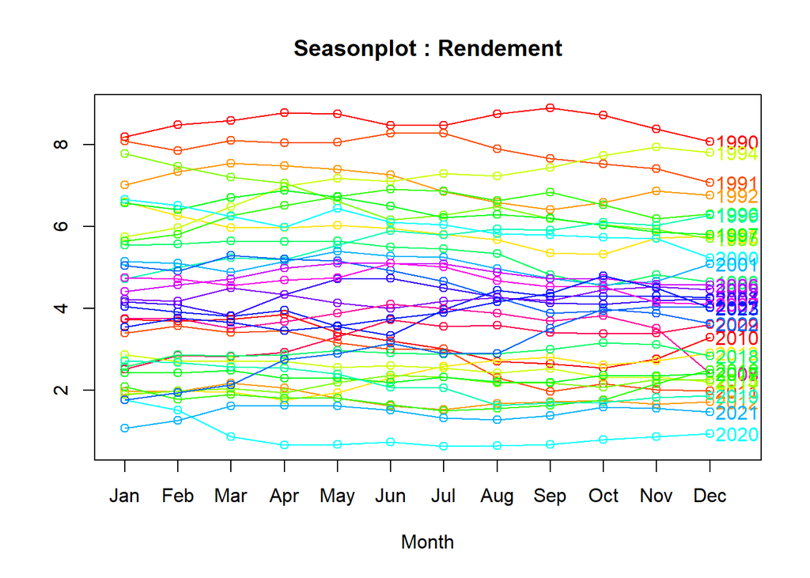

```r
seasonplot(ts_data_mensuelle, main = "Seasonplot : Rendement", year.labels = TRUE, col = rainbow(20))
```

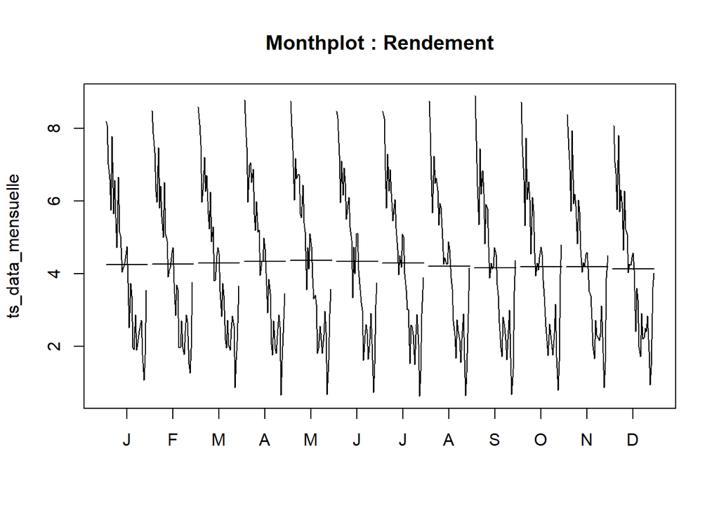

```r
monthplot(ts_data_mensuelle, main = "Monthplot : Rendement")
```

Le monthplotmet en évidence les variations moyennes pour chaque mois, affichant les tendances spécifiques et les fluctuations typiques au sein de chaque année. Cela permet de visualiser comment les rendements évoluent d’un mois à l’autre.

# STL (Seasonal Decomposition of Time Series by Loess)

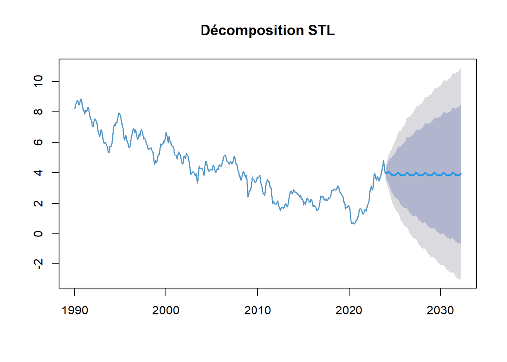

```r
stl_decomp <- stlf(ts_data_mensuelle, s.window = "periodic", h = 100)
plot(stl_decomp, col="#5A9AC7", lwd = 1.5, main = "Décomposition STL")
```

Le graphique issu de la méthode STLF montre des prévisions globalement constantes, suggérant une absence de tendance claire dans les données mais la presence des composantes saisonnières. L’intervalle de confiance large indique une forte incertitude quant à l’évolution future. Ce comportement reflète une stabilisation supposée à long terme, mais avec une prudence élevée quant à la précision des projections.

## Modèle ARIMA de la serie désaisonnalisé

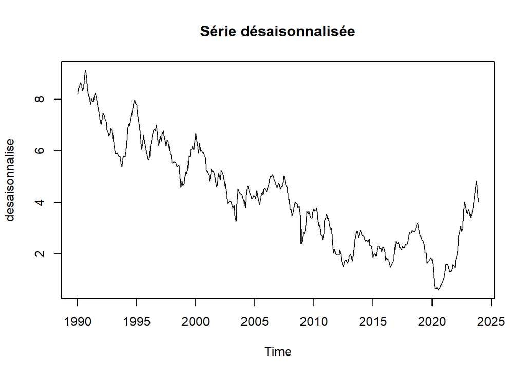

```r
desaisonnalise <- seasadj(decomp_mult)
plot(desaisonnalise, main = "Série désaisonnalisée", type = "l")
```

```r
model_arima <- auto.arima(desaisonnalise)
summary(model_arima)
```

```
## Series: desaisonnalise
## ARIMA(1,1,1)(1,0,0)[12]
##
## Coefficients:
##           ar1     ma1     sar1
##       -0.1072  0.4400  -0.0674
## s.e.   0.1279  0.1134   0.0506
##
## sigma^2 = 0.04356:  log likelihood = 61.62
## AIC=-115.23   AICc=-115.13   BIC=-99.2
##
## Training set error measures:
##                        ME      RMSE       MAE        MPE     MAPE     MASE
## Training set -0.008568533 0.2076751 0.1625136 -0.3373409 4.781098 0.216119
##                      ACF1
## Training set -0.002513478
```

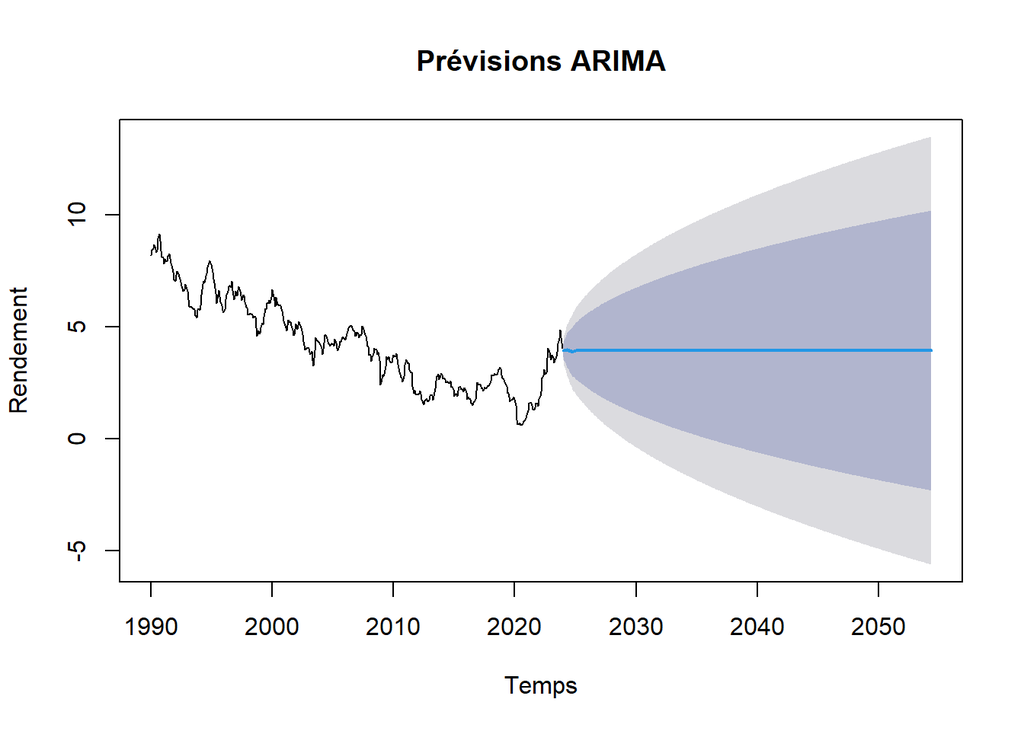

```r
forecast_arima <- forecast(model_arima, h = 365)
plot(forecast_arima, main = "Prévisions ARIMA", xlab = "Temps", ylab = "Rendement")
```

La série désaisonnalisée, obtenue après suppression des variations saisonnières, met en évidence la tendance et les fluctuations résiduelles.

Le modèle Auto ARIMA a été ajusté sur la série désaisonnalisée, fournissant un résumé des paramètres optimaux pour capturer les dynamiques sous-jacentes.

## Lissage exponentiel

```r
les_model <- ses(ts_data_mensuelle, alpha = 0.2, h = 100)
summary(les_model)
```

```
##
## Forecast method: Simple exponential smoothing
##
## Model Information:
## Simple exponential smoothing
##
## Call:
## ses(y = ts_data_mensuelle, h = 100, alpha = 0.2)
##
##   Smoothing parameters:
##     alpha = 0.2
##
##   Initial states:
##     l = 8.4747
##
##   sigma:  0.4277
##
##      AIC     AICc      BIC
## 1761.583 1761.612 1769.605
##
## Error measures:
##                       ME      RMSE       MAE       MPE     MAPE      MASE
## Training set -0.05352376 0.4266748 0.3432507 -3.099735 10.95037 0.4567043
##                   ACF1
## Training set 0.8549282
##
## Forecasts:
##          Point Forecast    Lo 80    Hi 80    Lo 95    Hi 95
## Jan 2024       4.107165 3.559014 4.655316 3.268840 4.945489
## Feb 2024       4.107165 3.548158 4.666171 3.252238 4.962091
## Mar 2024       4.107165 3.537509 4.676820 3.235952 4.978377
## Apr 2024       4.107165 3.527056 4.687273 3.219965 4.994364
## May 2024       4.107165 3.516788 4.697541 3.204261 5.010068
## Jun 2024       4.107165 3.506695 4.707634 3.188826 5.025503
## Jul 2024       4.107165 3.496769 4.717560 3.173646 5.040683
## Aug 2024       4.107165 3.487003 4.727327 3.158709 5.055620
## Sep 2024       4.107165 3.477387 4.736942 3.144003 5.070326
## Oct 2024       4.107165 3.467916 4.746413 3.129519 5.084811
## Nov 2024       4.107165 3.458584 4.755746 3.115246 5.099084
## Dec 2024       4.107165 3.449383 4.764946 3.101175 5.113154
```

[output cut: 73 more lines]

```
## Feb 2031       4.107165 2.957353 5.256976 2.348680 5.865649
## Mar 2031       4.107165 2.952139 5.262190 2.340705 5.873624
## Apr 2031       4.107165 2.946948 5.267381 2.332766 5.881563
## May 2031       4.107165 2.941780 5.272549 2.324862 5.889467
## Jun 2031       4.107165 2.936634 5.277695 2.316993 5.897336
## Jul 2031       4.107165 2.931512 5.282817 2.309159 5.905170
## Aug 2031       4.107165 2.926411 5.287918 2.301358 5.912971
## Sep 2031       4.107165 2.921333 5.292996 2.293591 5.920738
## Oct 2031       4.107165 2.916276 5.298053 2.285857 5.928472
## Nov 2031       4.107165 2.911240 5.303089 2.278156 5.936173
## Dec 2031       4.107165 2.906226 5.308103 2.270488 5.943842
## Jan 2032       4.107165 2.901232 5.313097 2.262851 5.951479
## Feb 2032       4.107165 2.896260 5.318070 2.255245 5.959084
## Mar 2032       4.107165 2.891307 5.323022 2.247671 5.966658
## Apr 2032       4.107165 2.886374 5.327955 2.240127 5.974202
```

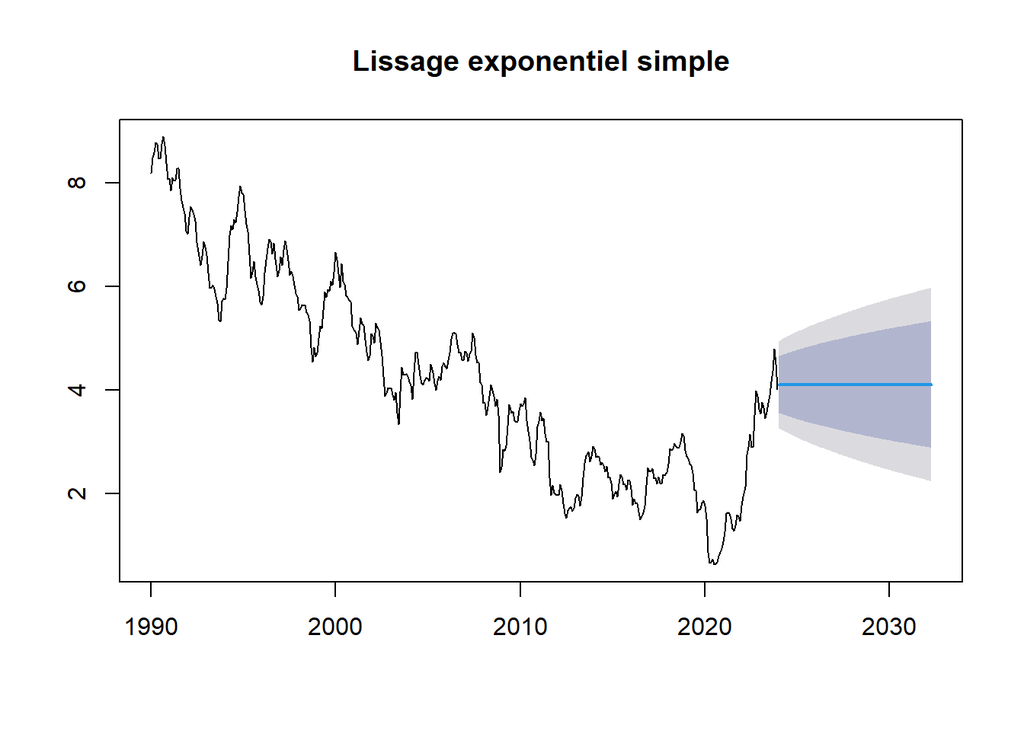

```r
plot(les_model, main = "Lissage exponentiel simple")
```

```r
holt_model <- holt(ts_data_mensuelle, h = 100)  #une tendance linéaire
summary(holt_model)
```

```
##
## Forecast method: Holt's method
##
## Model Information:
## Holt's method
##
## Call:
## holt(y = ts_data_mensuelle, h = 100)
##
##   Smoothing parameters:
##     alpha = 0.9999
##     beta  = 1e-04
##
##   Initial states:
##     l = 8.2168
##     b = -0.0103
##
##   sigma:  0.2216
##
##      AIC     AICc      BIC
## 1229.046 1229.196 1249.103
##
## Error measures:
##                       ME      RMSE       MAE        MPE     MAPE      MASE
## Training set 0.000137954 0.2205338 0.1698995 -0.1207627 5.015048 0.2260559
##                  ACF1
## Training set 0.282421
##
## Forecasts:
##          Point Forecast     Lo 80    Hi 80       Lo 95    Hi 95
## Jan 2024       4.003607 3.7195863 4.287629  3.56923458 4.437980
## Feb 2024       3.993358 3.5916911 4.395024  3.37906164 4.607654
## Mar 2024       3.983108 3.4911524 4.475063  3.23072688 4.735489
## Apr 2024       3.972858 3.4047731 4.540943  3.10404714 4.841669
## May 2024       3.962608 3.3274414 4.597775  2.99120440 4.934012
## Jun 2024       3.952359 3.2565356 4.648181  2.88818918 5.016528
## Jul 2024       3.942109 3.1904983 4.693719  2.79261973 5.091598
## Aug 2024       3.931859 3.1283148 4.735403  2.70294425 5.160774
## Sep 2024       3.921609 3.0692805 4.773938  2.61808492 5.225133
## Oct 2024       3.911359 3.0128821 4.809837  2.53725699 5.285462
```

[output cut: 75 more lines]

```
## Feb 2031       3.132375 0.4875271 5.777223 -0.91257090 7.177321
## Mar 2031       3.122125 0.4618121 5.782439 -0.94647271 7.190724
## Apr 2031       3.111876 0.4361834 5.787568 -0.98024246 7.203994
## May 2031       3.101626 0.4106396 5.792612 -1.01388243 7.217134
## Jun 2031       3.091376 0.3851793 5.797573 -1.04739481 7.230147
## Jul 2031       3.081126 0.3598009 5.802452 -1.08078174 7.243034
## Aug 2031       3.070877 0.3345032 5.807250 -1.11404531 7.255798
## Sep 2031       3.060627 0.3092849 5.811969 -1.14718753 7.268441
## Oct 2031       3.050377 0.2841446 5.816609 -1.18021038 7.280964
## Nov 2031       3.040127 0.2590811 5.821173 -1.21311578 7.293370
## Dec 2031       3.029877 0.2340932 5.825662 -1.24590559 7.305660
## Jan 2032       3.019628 0.2091796 5.830075 -1.27858163 7.317837
## Feb 2032       3.009378 0.1843393 5.834416 -1.31114568 7.329901
## Mar 2032       2.999128 0.1595711 5.838685 -1.34359946 7.341855
## Apr 2032       2.988878 0.1348739 5.842882 -1.37594466 7.353701
```

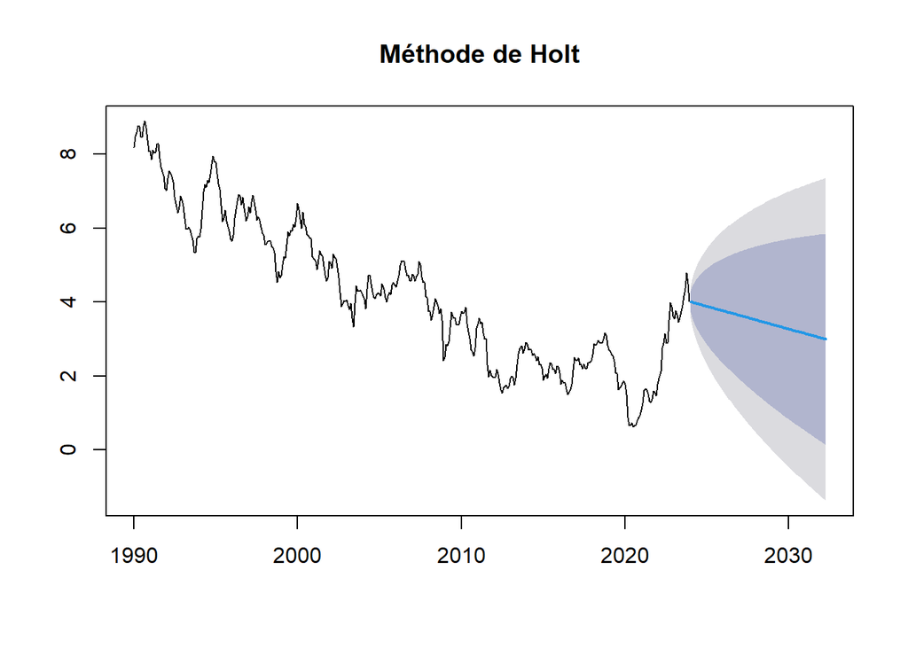

```r
plot(holt_model, main = "Méthode de Holt")
```

```r
holt_model <- holt(ts_data_mensuelle, h = 100)
summary(holt_model)
```

```
##
## Forecast method: Holt's method
##
## Model Information:
## Holt's method
##
## Call:
## holt(y = ts_data_mensuelle, h = 100)
##
##   Smoothing parameters:
##     alpha = 0.9999
##     beta  = 1e-04
##
##   Initial states:
##     l = 8.2168
##     b = -0.0103
##
##   sigma:  0.2216
##
##      AIC     AICc      BIC
## 1229.046 1229.196 1249.103
##
## Error measures:
##                       ME      RMSE       MAE        MPE     MAPE      MASE
## Training set 0.000137954 0.2205338 0.1698995 -0.1207627 5.015048 0.2260559
##                  ACF1
## Training set 0.282421
##
## Forecasts:
##          Point Forecast     Lo 80    Hi 80       Lo 95    Hi 95
## Jan 2024       4.003607 3.7195863 4.287629  3.56923458 4.437980
## Feb 2024       3.993358 3.5916911 4.395024  3.37906164 4.607654
## Mar 2024       3.983108 3.4911524 4.475063  3.23072688 4.735489
## Apr 2024       3.972858 3.4047731 4.540943  3.10404714 4.841669
## May 2024       3.962608 3.3274414 4.597775  2.99120440 4.934012
## Jun 2024       3.952359 3.2565356 4.648181  2.88818918 5.016528
## Jul 2024       3.942109 3.1904983 4.693719  2.79261973 5.091598
## Aug 2024       3.931859 3.1283148 4.735403  2.70294425 5.160774
## Sep 2024       3.921609 3.0692805 4.773938  2.61808492 5.225133
## Oct 2024       3.911359 3.0128821 4.809837  2.53725699 5.285462
```

[output cut: 75 more lines]

```
## Feb 2031       3.132375 0.4875271 5.777223 -0.91257090 7.177321
## Mar 2031       3.122125 0.4618121 5.782439 -0.94647271 7.190724
## Apr 2031       3.111876 0.4361834 5.787568 -0.98024246 7.203994
## May 2031       3.101626 0.4106396 5.792612 -1.01388243 7.217134
## Jun 2031       3.091376 0.3851793 5.797573 -1.04739481 7.230147
## Jul 2031       3.081126 0.3598009 5.802452 -1.08078174 7.243034
## Aug 2031       3.070877 0.3345032 5.807250 -1.11404531 7.255798
## Sep 2031       3.060627 0.3092849 5.811969 -1.14718753 7.268441
## Oct 2031       3.050377 0.2841446 5.816609 -1.18021038 7.280964
## Nov 2031       3.040127 0.2590811 5.821173 -1.21311578 7.293370
## Dec 2031       3.029877 0.2340932 5.825662 -1.24590559 7.305660
## Jan 2032       3.019628 0.2091796 5.830075 -1.27858163 7.317837
## Feb 2032       3.009378 0.1843393 5.834416 -1.31114568 7.329901
## Mar 2032       2.999128 0.1595711 5.838685 -1.34359946 7.341855
## Apr 2032       2.988878 0.1348739 5.842882 -1.37594466 7.353701
```

```r
plot(holt_model, main = "Méthode de Holt")

holt_damped_model <- holt(ts_data_mensuelle, damped = TRUE, h = 100)
summary(holt_damped_model)
```

[output not shown]

```
##
## Forecast method: Damped Holt's method
##
## Model Information:
## Damped Holt's method
##
## Call:
## holt(y = ts_data_mensuelle, h = 100, damped = TRUE)
##
##   Smoothing parameters:
##     alpha = 0.9998
##     beta  = 0.155
##     phi   = 0.8
##
##   Initial states:
##     l = 8.0729
##     b = 0.1896
##
##   sigma:  0.2192
##
##      AIC     AICc      BIC
## 1220.973 1221.183 1245.041
##
## Error measures:
##                        ME      RMSE       MAE        MPE     MAPE      MASE
## Training set -0.007603445 0.2178282 0.1707522 -0.2174241 5.058056 0.2271904
##                   ACF1
## Training set 0.1791429
##
## Forecasts:
##          Point Forecast       Lo 80    Hi 80       Lo 95     Hi 95
## Jan 2024       3.972288  3.69140322 4.253172  3.54271193  4.401864
## Feb 2024       3.938986  3.51644352 4.361529  3.29276280  4.585210
## Mar 2024       3.912345  3.36776959 4.456921  3.07948855  4.745202
## Apr 2024       3.891033  3.23498308 4.547082  2.88769143  4.894374
## May 2024       3.873982  3.11397619 4.633989  2.71165321  5.036312
## Jun 2024       3.860342  3.00245394 4.718230  2.54831534  5.172369
## Jul 2024       3.849430  2.89887658 4.799983  2.39568398  5.303176
## Aug 2024       3.840700  2.80209902 4.879302  2.25229672  5.429104
## Sep 2024       3.833716  2.71121824 4.956215  2.11700355  5.550429
```

[output cut: 76 more lines]

```
## Feb 2031       3.805781 -0.32922251 7.940785 -2.51816133 10.129724
## Mar 2031       3.805781 -0.35418386 7.965747 -2.55633642 10.167899
## Apr 2031       3.805781 -0.37899632 7.990559 -2.59428380 10.205847
## May 2031       3.805781 -0.40366253 8.015225 -2.63200751 10.243570
## Jun 2031       3.805781 -0.42818504 8.039748 -2.66951146 10.281074
## Jul 2031       3.805781 -0.45256633 8.064129 -2.70679943 10.318362
## Aug 2031       3.805781 -0.47680882 8.088372 -2.74387512 10.355438
## Sep 2031       3.805781 -0.50091486 8.112478 -2.78074211 10.392305
## Oct 2031       3.805781 -0.52488671 8.136449 -2.81740390 10.428967
## Nov 2031       3.805781 -0.54872659 8.160289 -2.85386386 10.465427
## Dec 2031       3.805781 -0.57243667 8.183999 -2.89012529 10.501688
## Jan 2032       3.805781 -0.59601904 8.207582 -2.92619141 10.537754
## Feb 2032       3.805781 -0.61947574 8.231038 -2.96206533 10.573628
## Mar 2032       3.805781 -0.64280875 8.254371 -2.99775010 10.609313
## Apr 2032       3.805781 -0.66602002 8.277583 -3.03324867 10.644811
```

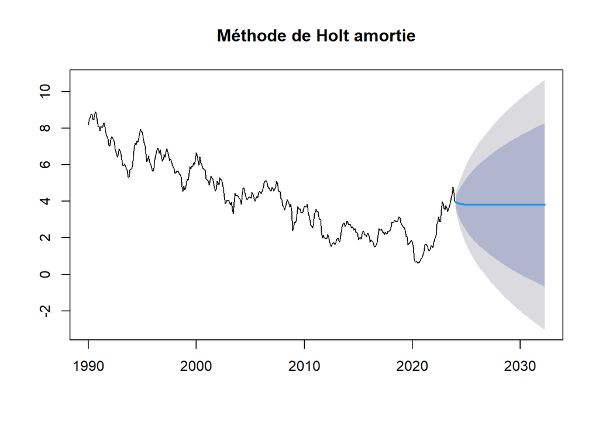

```r
plot(holt_damped_model, main = "Méthode de Holt amortie")
```

Le modèle de Holt, intégrant une tendance linéaire, révèle une légère baisse par rapport au lissage exponentiel simple. Cela indique que les données récentes montrent une tendance décroissante.

Le modèle de Holt avec tendance amortie montre des prévisions quasiment constantes, reflétant une tendance stabilisée sur le long terme. Cependant, l’intervalle de confiance très large indique une grande incertitude quant à l’évolution future des données.

## Tests statistiques

```r
# Test de Box-Pierce
Box.test(ts_data_mensuelle, lag = 10, type = "Box-Pierce")
```

```
##
##  Box-Pierce test
##
## data:  ts_data_mensuelle
## X-squared = 3478.1, df = 10, p-value < 2.2e-16
```

```r
# Test de Ljung-Box
Box.test(ts_data_mensuelle, lag = 10, type = "Ljung-Box")
```

```
##
##  Box-Ljung test
##
## data:  ts_data_mensuelle
## X-squared = 3540.8, df = 10, p-value < 2.2e-16
```

les deux p-value des deux tests extrêmement faible (< 0.05), nous rejetons également les hypothèses nulles cela nous confirme qu’il existe une autocorrélation significative dans les 10 premiers lags de la série.

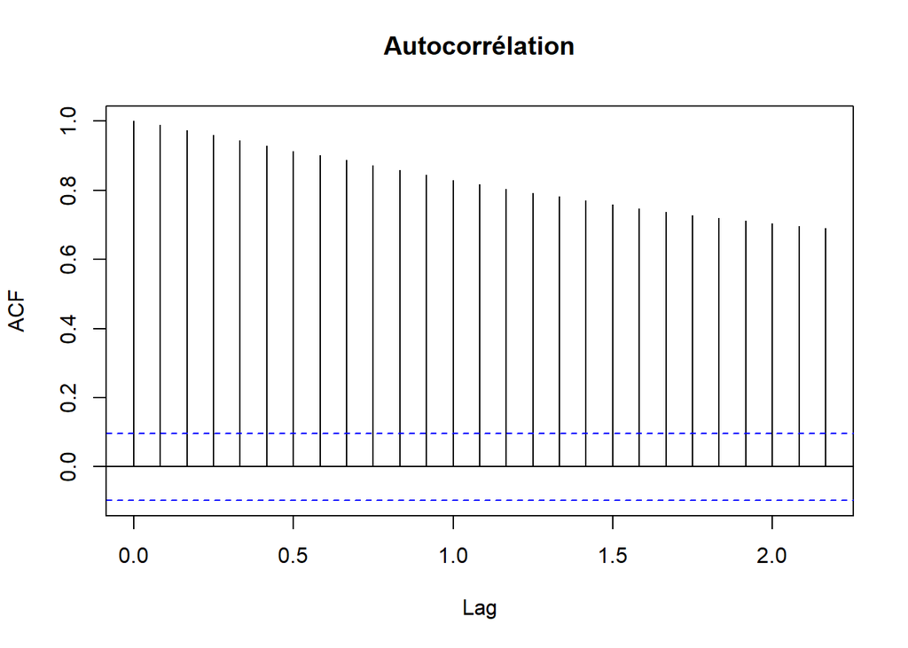

```r
acf(ts_data_mensuelle, main = "Autocorrélation")
```

Les autocorrélations pour les premiers lags sont fortes et significatives, Cela indique une dépendance temporelle importante entre les observations proches dans la série. Les autocorrélations diminuent progressivement avec l’augmentation du lag, ce qui nous montre une présentant d’une structure de tendance ou de saisonnalité. Les fortes autocorrélations initiales suggèrent que des transformations comme la différenciation pourraient être nécessaires pour la modélisation.

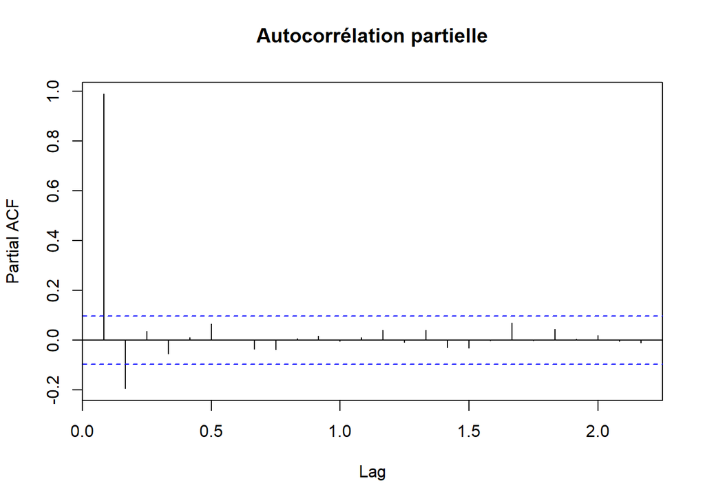

```r
pacf(ts_data_mensuelle, main = "Autocorrélation partielle")
```

```r
adf.test(ts_data_mensuelle, alternative = "stationary")
```

```
##
##  Augmented Dickey-Fuller Test
##
## data:  ts_data_mensuelle
## Dickey-Fuller = -2.4271, Lag order = 7, p-value = 0.3969
## alternative hypothesis: stationary
```

Le test ADF indique que notre série n’est pas stationnaire (p-value = 0.3969) alors on garde L’hypothèse nulle H0. Pour effectuer des modélisations, il est recommandé de transformer les données pour atteindre la stationnarité, par exemple en appliquant une différenciation.